# Subscription Prediction with PySpark and MLlib

## Learning Objectives

At the end of this session, you will be able to

- Explore data with Spark DataFrames
- Build a pipeline in MLlib for machine learning workflow
- Fit a logistic regression model, make predictions, and evaluate the model

## Part 1: Data Loader

We are using a dataset from the UCI Machine Learning Repository.

1. Use `wget` to download the dataset. Then use `ls` to verify that the `bank.zip` file is downloaded.

```python
%%sh
wget https://archive.ics.uci.edu/ml/machine-learning-databases/00222/bank.zip
```

```
--2022-05-27 05:42:33--  https://archive.ics.uci.edu/ml/machine-learning-databases/00222/bank.zip
Resolving archive.ics.uci.edu (archive.ics.uci.edu)... 128.195.10.252
Connecting to archive.ics.uci.edu (archive.ics.uci.edu)|128.195.10.252|:443... connected.
HTTP request sent, awaiting response... 200 OK
Length: 579043 (565K) [application/x-httpd-php]
Saving to: ‘bank.zip’

     0K .......... .......... .......... .......... ..........  8%  830K 1s
    50K .......... .......... .......... .......... .......... 17%  886K 1s
   100K .......... .......... .......... .......... .......... 26% 1.71M 0s
   150K .......... .......... .......... .......... .......... 35% 1.68M 0s
   200K .......... .......... .......... .......... .......... 44% 67.9M 0s
   250K .......... .......... .......... .......... .......... 53% 1.73M 0s
   300K .......... .......... .......... .......... .......... 61% 63.0M 0s
   350K .......... .......... .......... .......... .......... 70% 42.5M 0s
   400K .......... .......... .......... .......... .......... 79% 24.6M 0s
   450K .......... .......... .......... .......... .......... 88% 2.05M 0s
   500K .......... .......... .......... .......... .......... 97% 77.1M 0s
   550K .......... .....                                      100% 96.8M=0.2s

2022-05-27 05:42:33 (2.38 MB/s) - ‘bank.zip’ saved [579043/579043]
```

```python
ls
```

```
bank.zip  conf/  eventlogs/  logs/  metastore_db/  preload_class.lst*
```

1. Unzip the file and use `ls` to see the files.

```python
%%sh
unzip bank.zip
```

```
Archive:  bank.zip
  inflating: bank-full.csv
  inflating: bank-names.txt
  inflating: bank.csv
```

```python
ls
```

```
bank-full.csv   bank.csv  conf/       logs/          preload_class.lst*
bank-names.txt  bank.zip  eventlogs/  metastore_db/
```

## Part 2: Exploring The Data

We will use the direct marketing campaigns (phone calls) of a Portuguese banking institution. The classification goal is to predict whether the client will subscribe (Yes/No) to a term deposit.

1. Load in the data and look at the columns.

```python
from pyspark.sql import SparkSession

spark = SparkSession.builder.appName('ml-bank').getOrCreate()
df = spark.read.csv('file:/databricks/driver/bank.csv', header=True, inferSchema=True, sep=';')
df.printSchema()
```

```
root
 |-- age: integer (nullable = true)
 |-- job: string (nullable = true)
 |-- marital: string (nullable = true)
 |-- education: string (nullable = true)
 |-- default: string (nullable = true)
 |-- balance: integer (nullable = true)
 |-- housing: string (nullable = true)
 |-- loan: string (nullable = true)
 |-- contact: string (nullable = true)
 |-- day: integer (nullable = true)
 |-- month: string (nullable = true)
 |-- duration: integer (nullable = true)
 |-- campaign: integer (nullable = true)
 |-- pdays: integer (nullable = true)
 |-- previous: integer (nullable = true)
 |-- poutcome: string (nullable = true)
 |-- y: string (nullable = true)
```

Here are the columns you should see:

- Input variables: age, job, marital, education, default, balance, housing, loan, contact, day, month, duration, campaign, pdays, previous, poutcome
- Output variable: y (deposit)
1. Have a peek of the first five observations. Use the `.show()` method.

```python
df.show(5)
```

```
+---+-----------+-------+---------+-------+-------+-------+----+--------+---+-----+--------+--------+-----+--------+--------+---+
|age|        job|marital|education|default|balance|housing|loan| contact|day|month|duration|campaign|pdays|previous|poutcome|  y|
+---+-----------+-------+---------+-------+-------+-------+----+--------+---+-----+--------+--------+-----+--------+--------+---+
| 30| unemployed|married|  primary|     no|   1787|     no|  no|cellular| 19|  oct|      79|       1|   -1|       0| unknown| no|
| 33|   services|married|secondary|     no|   4789|    yes| yes|cellular| 11|  may|     220|       1|  339|       4| failure| no|
| 35| management| single| tertiary|     no|   1350|    yes|  no|cellular| 16|  apr|     185|       1|  330|       1| failure| no|
| 30| management|married| tertiary|     no|   1476|    yes| yes| unknown|  3|  jun|     199|       4|   -1|       0| unknown| no|
| 59|blue-collar|married|secondary|     no|      0|    yes|  no| unknown|  5|  may|     226|       1|   -1|       0| unknown| no|
+---+-----------+-------+---------+-------+-------+-------+----+--------+---+-----+--------+--------+-----+--------+--------+---+
only showing top 5 rows
```

1. To get a prettier result, it can be nice to use Pandas to display the smaller DataFrame. Use the Spark `.take()` method to get the first 5 rows and then convert to a pandas DataFrame. Don't forget to pass along the column names. You should see the same result as above, but in a more aesthetically appealing format.

```python
import pandas as pd

pd.DataFrame(df.take(5))
```

|  | 0 | 1 | 2 | 3 | 4 | 5 | 6 | 7 | 8 | 9 | 10 | 11 | 12 | 13 | 14 | 15 | 16 |
| --- | --- | --- | --- | --- | --- | --- | --- | --- | --- | --- | --- | --- | --- | --- | --- | --- | --- |
| 0 | 30 | unemployed | married | primary | no | 1787 | no | no | cellular | 19 | oct | 79 | 1 | -1 | 0 | unknown | no |
| 1 | 33 | services | married | secondary | no | 4789 | yes | yes | cellular | 11 | may | 220 | 1 | 339 | 4 | failure | no |
| 2 | 35 | management | single | tertiary | no | 1350 | yes | no | cellular | 16 | apr | 185 | 1 | 330 | 1 | failure | no |
| 3 | 30 | management | married | tertiary | no | 1476 | yes | yes | unknown | 3 | jun | 199 | 4 | -1 | 0 | unknown | no |
| 4 | 59 | blue-collar | married | secondary | no | 0 | yes | no | unknown | 5 | may | 226 | 1 | -1 | 0 | unknown | no |

1. How many datapoints are there in the dataset? Use the `.count()` method.

```python
df.count()
```

```
Out[8]: 4521
```

1. Use the `.describe()` method to see summary statistics on the features.

   Note that the result of `.describe()` is a Spark DataFrame, so the contents won't be displayed. It only has 5 rows, so you can just convert the whole thing to a pandas DataFrame with `.toPandas()`.

```python
df.describe().toPandas()
```

|  | summary | age | job | marital | education | default | balance | housing | loan | contact | day | month | duration | campaign | pdays | previous | poutcome | y |
| --- | --- | --- | --- | --- | --- | --- | --- | --- | --- | --- | --- | --- | --- | --- | --- | --- | --- | --- |
| 0 | count | 4521 | 4521 | 4521 | 4521 | 4521 | 4521 | 4521 | 4521 | 4521 | 4521 | 4521 | 4521 | 4521 | 4521 | 4521 | 4521 | 4521 |
| 1 | mean | 41.17009511170095 | None | None | None | None | 1422.6578190665782 | None | None | None | 15.915284229152842 | None | 263.96129174961294 | 2.793629727936297 | 39.766644547666445 | 0.5425790754257908 | None | None |
| 2 | stddev | 10.576210958711263 | None | None | None | None | 3009.6381424673395 | None | None | None | 8.247667327229934 | None | 259.85663262468216 | 3.1098066601885823 | 100.12112444301656 | 1.6935623506071211 | None | None |
| 3 | min | 19 | admin. | divorced | primary | no | -3313 | no | no | cellular | 1 | apr | 4 | 1 | -1 | 0 | failure | no |
| 4 | max | 87 | unknown | single | unknown | yes | 71188 | yes | yes | unknown | 31 | sep | 3025 | 50 | 871 | 25 | unknown | yes |

1. The above result includes the columns that are categorical, so don't have useful summary statistics. Let's limit to just the numeric features.

   `numeric_features` is defined below to contain the column names of the numeric features.

```python
numeric_features = [name for name, dtype in df.dtypes if dtype == 'int']
df.select(numeric_features).toPandas()
```

|  | age | balance | day | duration | campaign | pdays | previous |
| --- | --- | --- | --- | --- | --- | --- | --- |
| 0 | 30 | 1787 | 19 | 79 | 1 | -1 | 0 |
| 1 | 33 | 4789 | 11 | 220 | 1 | 339 | 4 |
| 2 | 35 | 1350 | 16 | 185 | 1 | 330 | 1 |
| 3 | 30 | 1476 | 3 | 199 | 4 | -1 | 0 |
| 4 | 59 | 0 | 5 | 226 | 1 | -1 | 0 |
| ... | ... | ... | ... | ... | ... | ... | ... |
| 4516 | 33 | -333 | 30 | 329 | 5 | -1 | 0 |
| 4517 | 57 | -3313 | 9 | 153 | 1 | -1 | 0 |
| 4518 | 57 | 295 | 19 | 151 | 11 | -1 | 0 |
| 4519 | 28 | 1137 | 6 | 129 | 4 | 211 | 3 |
| 4520 | 44 | 1136 | 3 | 345 | 2 | 249 | 7 |

4521 rows × 7 columns

1. Run the following code to look at correlation between the numeric features. What do you see?

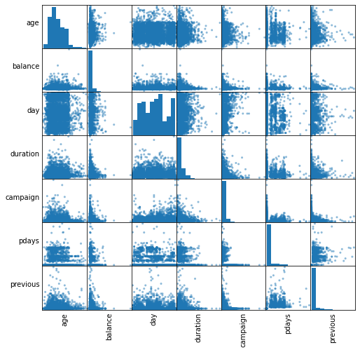

```python
numeric_data = df.select(numeric_features).toPandas()
axs = pd.plotting.scatter_matrix(numeric_data, figsize=(8, 8));
n = len(numeric_data.columns)

for i in range(n):
    v = axs[i, 0]
    v.yaxis.label.set_rotation(0)
    v.yaxis.label.set_ha('right')
    v.set_yticks(())
    h = axs[n - 1, i]
    h.xaxis.label.set_rotation(90)
    h.set_xticks(())
```

There aren't any highly correlated variables, so we will keep them all for the model. It’s obvious that there aren’t highly correlated numeric variables. Therefore, we will keep all of them for the model. However, day and month columns are not really useful, so we will remove these two columns.

1. Use the `.drop()` method to drop the `month` and `day` columns.

   Note that this method returns a new DataFrame, so save that result as `df`.

   Use the `.printSchema()` method to verify that `df` now has the correct columns.

```python
df = df.drop('month','day')
```

## Part 3: Preparing Data for Machine Learning

What follows is something analagous to a dataloader pipeline in Tensorflow--we're going to chain together some transformations that will convert our categorical variables into a one-hot format more amenable to training a machine learning model. The next code cell just sets this all up, it doesn't yet run these transformations on our data.

The process includes Category Indexing, One-Hot Encoding and VectorAssembler — a feature transformer that merges multiple columns into a vector column.

The code is taken from [databricks’ official site](https://docs.databricks.com/applications/machine-learning/train-model/mllib/index.html#binary-classification-example) and it indexes each categorical column using the StringIndexer, then converts the indexed categories into one-hot encoded variables. The resulting output has the binary vectors appended to the end of each row. We use the StringIndexer again to encode our labels to label indices. Next, we use the VectorAssembler to combine all the feature columns into a single vector column.

1. Complete the code by completing the assignment of `assembler`. Use `VectorAssembler` and pass in `assemblerInputs` as `inputCols` and name the `outputCol` `"features"`.

```python
from pyspark.ml.feature import OneHotEncoder , StringIndexer, VectorAssembler

categoricalColumns = ['job', 'marital', 'education', 'default', 'housing', 'loan', 'contact', 'poutcome']
stages = []

for categoricalCol in categoricalColumns:
    stringIndexer = StringIndexer(inputCol = categoricalCol, outputCol = categoricalCol + 'Index')
    encoder = OneHotEncoder(inputCols=[stringIndexer.getOutputCol()], outputCols=[categoricalCol + "classVec"])
    stages += [stringIndexer, encoder]

label_stringIdx = StringIndexer(inputCol = 'y', outputCol = 'label')
stages += [label_stringIdx]
numericCols = ['age', 'balance', 'duration', 'campaign', 'pdays', 'previous']
assemblerInputs = [c + "classVec" for c in categoricalColumns] + numericCols
assembler = VectorAssembler(inputCols = assemblerInputs,outputCol="features") # [YOUR CODE HERE]
stages += [assembler]
```

## Part 4: Pipeline

We use Pipeline to chain multiple Transformers and Estimators together to specify our machine learning workflow. A Pipeline’s stages are specified as an ordered array.

1. Fit a pipeline on df.

```python
from pyspark.ml import Pipeline
pipeline = Pipeline(stages=stages)

pipelineModel = pipeline.fit(df) # [YOUR CODE HERE]
```

1. Transform `pipelineModel` on `df` and assign this to variable `transformed_df`.

```python
transformed_df = pipelineModel.transform(df) # [YOUR CODE HERE]
transformed_df.printSchema()
```

```
root
 |-- age: integer (nullable = true)
 |-- job: string (nullable = true)
 |-- marital: string (nullable = true)
 |-- education: string (nullable = true)
 |-- default: string (nullable = true)
 |-- balance: integer (nullable = true)
 |-- housing: string (nullable = true)
 |-- loan: string (nullable = true)
 |-- contact: string (nullable = true)
 |-- duration: integer (nullable = true)
 |-- campaign: integer (nullable = true)
 |-- pdays: integer (nullable = true)
 |-- previous: integer (nullable = true)
 |-- poutcome: string (nullable = true)
 |-- y: string (nullable = true)
 |-- jobIndex: double (nullable = false)
 |-- jobclassVec: vector (nullable = true)
 |-- maritalIndex: double (nullable = false)
 |-- maritalclassVec: vector (nullable = true)
 |-- educationIndex: double (nullable = false)
 |-- educationclassVec: vector (nullable = true)
 |-- defaultIndex: double (nullable = false)
 |-- defaultclassVec: vector (nullable = true)
 |-- housingIndex: double (nullable = false)
 |-- housingclassVec: vector (nullable = true)
 |-- loanIndex: double (nullable = false)
 |-- loanclassVec: vector (nullable = true)
 |-- contactIndex: double (nullable = false)
 |-- contactclassVec: vector (nullable = true)
 |-- poutcomeIndex: double (nullable = false)
 |-- poutcomeclassVec: vector (nullable = true)
 |-- label: double (nullable = false)
 |-- features: vector (nullable = true)
```

From the transformation, we'd like to take the `label` and `features` columns as well as the original columns from `df.`

1. Use the `.select()` method to pull these columns from the `transformed_df` and reassign the resulting DataFrame to `df`.

```python
selectedCols = ['label', 'features'] + df.columns
df = transformed_df.select(selectedCols) #
df.printSchema()
```

```
root
 |-- label: double (nullable = false)
 |-- features: vector (nullable = true)
 |-- age: integer (nullable = true)
 |-- job: string (nullable = true)
 |-- marital: string (nullable = true)
 |-- education: string (nullable = true)
 |-- default: string (nullable = true)
 |-- balance: integer (nullable = true)
 |-- housing: string (nullable = true)
 |-- loan: string (nullable = true)
 |-- contact: string (nullable = true)
 |-- duration: integer (nullable = true)
 |-- campaign: integer (nullable = true)
 |-- pdays: integer (nullable = true)
 |-- previous: integer (nullable = true)
 |-- poutcome: string (nullable = true)
 |-- y: string (nullable = true)
```

1. View the first five rows of the `df` DataFrame. Use either of the methods we did in Part 2:
   - `.show()` method
   - `.take()` method and convert result to a Pandas DataFrame

```python
df.show()
pd.DataFrame(df.take(5))
```

```
+-----+--------------------+---+-------------+-------+---------+-------+-------+-------+----+--------+--------+--------+-----+--------+--------+---+
|label|            features|age|          job|marital|education|default|balance|housing|loan| contact|duration|campaign|pdays|previous|poutcome|  y|
+-----+--------------------+---+-------------+-------+---------+-------+-------+-------+----+--------+--------+--------+-----+--------+--------+---+
|  0.0|(30,[8,11,15,16,1...| 30|   unemployed|married|  primary|     no|   1787|     no|  no|cellular|      79|       1|   -1|       0| unknown| no|
|  0.0|(30,[4,11,13,16,1...| 33|     services|married|secondary|     no|   4789|    yes| yes|cellular|     220|       1|  339|       4| failure| no|
|  0.0|(30,[0,12,14,16,1...| 35|   management| single| tertiary|     no|   1350|    yes|  no|cellular|     185|       1|  330|       1| failure| no|
|  0.0|(30,[0,11,14,16,1...| 30|   management|married| tertiary|     no|   1476|    yes| yes| unknown|     199|       4|   -1|       0| unknown| no|
|  0.0|(30,[1,11,13,16,1...| 59|  blue-collar|married|secondary|     no|      0|    yes|  no| unknown|     226|       1|   -1|       0| unknown| no|
|  0.0|(30,[0,12,14,16,1...| 35|   management| single| tertiary|     no|    747|     no|  no|cellular|     141|       2|  176|       3| failure| no|
|  0.0|(30,[6,11,14,16,1...| 36|self-employed|married| tertiary|     no|    307|    yes|  no|cellular|     341|       1|  330|       2|   other| no|
|  0.0|(30,[2,11,13,16,1...| 39|   technician|married|secondary|     no|    147|    yes|  no|cellular|     151|       2|   -1|       0| unknown| no|
|  0.0|(30,[7,11,14,16,1...| 41| entrepreneur|married| tertiary|     no|    221|    yes|  no| unknown|      57|       2|   -1|       0| unknown| no|
|  0.0|(30,[4,11,15,16,1...| 43|     services|married|  primary|     no|    -88|    yes| yes|cellular|     313|       1|  147|       2| failure| no|
|  0.0|(30,[4,11,13,16,1...| 39|     services|married|secondary|     no|   9374|    yes|  no| unknown|     273|       1|   -1|       0| unknown| no|
|  0.0|(30,[3,11,13,16,1...| 43|       admin.|married|secondary|     no|    264|    yes|  no|cellular|     113|       2|   -1|       0| unknown| no|
|  0.0|(30,[2,11,14,16,1...| 36|   technician|married| tertiary|     no|   1109|     no|  no|cellular|     328|       2|   -1|       0| unknown| no|
|  1.0|(30,[10,12,13,16,...| 20|      student| single|secondary|     no|    502|     no|  no|cellular|     261|       1|   -1|       0| unknown|yes|
|  0.0|(30,[1,11,13,16,1...| 31|  blue-collar|married|secondary|     no|    360|    yes| yes|cellular|      89|       1|  241|       1| failure| no|
|  0.0|(30,[0,11,14,16,1...| 40|   management|married| tertiary|     no|    194|     no| yes|cellular|     189|       2|   -1|       0| unknown| no|
|  0.0|(30,[2,11,13,16,1...| 56|   technician|married|secondary|     no|   4073|     no|  no|cellular|     239|       5|   -1|       0| unknown| no|
|  0.0|(30,[3,12,14,16,1...| 37|       admin.| single| tertiary|     no|   2317|    yes|  no|cellular|     114|       1|  152|       2| failure| no|
|  0.0|(30,[1,12,15,16,1...| 25|  blue-collar| single|  primary|     no|   -221|    yes|  no| unknown|     250|       1|   -1|       0| unknown| no|
|  0.0|(30,[4,11,13,16,1...| 31|     services|married|secondary|     no|    132|     no|  no|cellular|     148|       1|  152|       1|   other| no|
+-----+--------------------+---+-------------+-------+---------+-------+-------+-------+----+--------+--------+--------+-----+--------+--------+---+
only showing top 20 rows
```

|  | 0 | 1 | 2 | 3 | 4 | 5 | 6 | 7 | 8 | 9 | 10 | 11 | 12 | 13 | 14 | 15 | 16 |
| --- | --- | --- | --- | --- | --- | --- | --- | --- | --- | --- | --- | --- | --- | --- | --- | --- | --- |
| 0 | 0.0 | (0.0, 0.0, 0.0, 0.0, 0.0, 0.0, 0.0, 0.0, 1.0, ... | 30 | unemployed | married | primary | no | 1787 | no | no | cellular | 79 | 1 | -1 | 0 | unknown | no |
| 1 | 0.0 | (0.0, 0.0, 0.0, 0.0, 1.0, 0.0, 0.0, 0.0, 0.0, ... | 33 | services | married | secondary | no | 4789 | yes | yes | cellular | 220 | 1 | 339 | 4 | failure | no |
| 2 | 0.0 | (1.0, 0.0, 0.0, 0.0, 0.0, 0.0, 0.0, 0.0, 0.0, ... | 35 | management | single | tertiary | no | 1350 | yes | no | cellular | 185 | 1 | 330 | 1 | failure | no |
| 3 | 0.0 | (1.0, 0.0, 0.0, 0.0, 0.0, 0.0, 0.0, 0.0, 0.0, ... | 30 | management | married | tertiary | no | 1476 | yes | yes | unknown | 199 | 4 | -1 | 0 | unknown | no |
| 4 | 0.0 | (0.0, 1.0, 0.0, 0.0, 0.0, 0.0, 0.0, 0.0, 0.0, ... | 59 | blue-collar | married | secondary | no | 0 | yes | no | unknown | 226 | 1 | -1 | 0 | unknown | no |

   Hint: Call the `.randomSplit()` method.

```python
train, test = df.randomSplit(weights = [0.80, 0.20], seed = 13)
```

1. What are the sizes of the training and test sets?

```python
print(train.count(),len(train.columns))
print(test.count(),len(test.columns))
```

```
3641 17
880 17
```

## Part 5: Logistic Regression Model

- You can build a RandomForestClassifier with : from pyspark.ml.classification import RandomForestClassifier
- You can build a Gradient-Boosted Tree Classifier with : from pyspark.ml.classification import GBTClassifier
1. Fit a LogisticRegression with `featuresCol` as `"features"`, `labelCol` as `"label"` and a `maxIter` of 10.

```python
from pyspark.ml.classification import LogisticRegression

Model = LogisticRegression(featuresCol='features',labelCol='label',maxIter=10)
lrModel = Model.fit(train)
```

1. We can obtain the coefficients by using LogisticRegressionModel’s attributes. Look at the following plot of the beta coefficients.

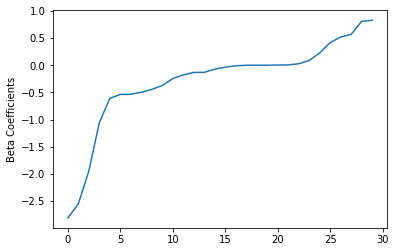

```python
import matplotlib.pyplot as plt
import numpy as np
beta = np.sort(lrModel.coefficients)
plt.plot(beta)
plt.ylabel('Beta Coefficients')
plt.show()
```

[figure not shown]

```
Training set areaUnderROC: 0.8817240616561219
```

```python
trainingSummary = lrModel.summary
roc = trainingSummary.roc.toPandas()
plt.plot(roc['FPR'],roc['TPR'])
plt.ylabel('False Positive Rate')
plt.xlabel('True Positive Rate')
plt.title('ROC Curve')
plt.show()
print('Training set areaUnderROC: ' + str(trainingSummary.areaUnderROC))
```

1. Use the `.transform()` method to make predictions and save them as `predictions`.

```python
predictions = lrModel.transform(test) # [YOUR CODE HERE]
```

1. View the first 10 rows of the `predictions` DataFrame.

```python
pd.DataFrame(predictions.take(10))
```

|  | 0 | 1 | 2 | 3 | 4 | 5 | 6 | 7 | 8 | 9 | 10 | 11 | 12 | 13 | 14 | 15 | 16 | 17 | 18 | 19 |
| --- | --- | --- | --- | --- | --- | --- | --- | --- | --- | --- | --- | --- | --- | --- | --- | --- | --- | --- | --- | --- |
| 0 | 0.0 | (1.0, 0.0, 0.0, 0.0, 0.0, 0.0, 0.0, 0.0, 0.0, ... | 31 | management | married | secondary | no | 1368 | yes | no | cellular | 129 | 4 | -1 | 0 | unknown | no | [3.296113646580294, -3.296113646580294] | [0.9642952450450218, 0.03570475495497816] | 0.0 |
| 1 | 0.0 | (1.0, 0.0, 0.0, 0.0, 0.0, 0.0, 0.0, 0.0, 0.0, ... | 34 | management | married | secondary | no | 1007 | yes | no | cellular | 240 | 2 | -1 | 0 | unknown | no | [2.699869439503001, -2.699869439503001] | [0.9370189394271383, 0.06298106057286168] | 0.0 |
| 2 | 0.0 | (1.0, 0.0, 0.0, 0.0, 0.0, 0.0, 0.0, 0.0, 0.0, ... | 56 | management | married | secondary | no | 238 | yes | no | cellular | 808 | 1 | -1 | 0 | unknown | no | [0.2830717613857957, -0.2830717613857957] | [0.5702991457289583, 0.42970085427104165] | 0.0 |
| 3 | 0.0 | (1.0, 0.0, 0.0, 0.0, 0.0, 0.0, 0.0, 0.0, 0.0, ... | 34 | management | married | secondary | no | -294 | yes | no | unknown | 532 | 2 | -1 | 0 | unknown | no | [2.7037982370546283, -2.7037982370546283] | [0.9372503975385852, 0.06274960246141481] | 0.0 |
| 4 | 0.0 | (1.0, 0.0, 0.0, 0.0, 0.0, 0.0, 0.0, 0.0, 0.0, ... | 34 | management | married | secondary | no | 293 | yes | no | unknown | 162 | 3 | -1 | 0 | unknown | no | [4.229996716232561, -4.229996716232561] | [0.9856562975108111, 0.014343702489188925] | 0.0 |
| 5 | 0.0 | (1.0, 0.0, 0.0, 0.0, 0.0, 0.0, 0.0, 0.0, 0.0, ... | 35 | management | married | secondary | no | 1160 | yes | no | unknown | 116 | 3 | -1 | 0 | unknown | no | [4.402061697393066, -4.402061697393066] | [0.9878962420750222, 0.012103757924977754] | 0.0 |
| 6 | 0.0 | (1.0, 0.0, 0.0, 0.0, 0.0, 0.0, 0.0, 0.0, 0.0, ... | 36 | management | married | secondary | no | 80 | yes | no | unknown | 251 | 3 | -1 | 0 | unknown | no | [3.8705234453013353, -3.8705234453013353] | [0.9795782866639472, 0.020421713336052805] | 0.0 |
| 7 | 0.0 | (1.0, 0.0, 0.0, 0.0, 0.0, 0.0, 0.0, 0.0, 0.0, ... | 42 | management | married | secondary | no | 2416 | yes | no | unknown | 138 | 4 | -1 | 0 | unknown | no | [4.347082665679956, -4.347082665679956] | [0.9872208983056818, 0.012779101694318173] | 0.0 |
| 8 | 0.0 | (1.0, 0.0, 0.0, 0.0, 0.0, 0.0, 0.0, 0.0, 0.0, ... | 52 | management | married | secondary | no | 428 | yes | no | unknown | 153 | 1 | -1 | 0 | unknown | no | [4.027185460095813, -4.027185460095813] | [0.9824877193855377, 0.017512280614462306] | 0.0 |
| 9 | 0.0 | (1.0, 0.0, 0.0, 0.0, 0.0, 0.0, 0.0, 0.0, 0.0, ... | 42 | management | married | secondary | no | 1331 | no | no | cellular | 698 | 2 | -1 | 0 | unknown | no | [0.3577804470693918, -0.3577804470693918] | [0.5885030368979528, 0.4114969631020472] | 0.0 |

1. What is the area under the ROC curve?

   You can find it with the `evaluator.evaluate()` function.

```python
from pyspark.ml.evaluation import BinaryClassificationEvaluator

evaluator = BinaryClassificationEvaluator()
evaluator.evaluate(predictions)
```

```
Out[35]: 0.890667366395529
```

## OPTIONAL: HyperParameter Tuning a Gradient-Boosted Tree Classifier

1. Fit and make predictions using `GBTClassifier`. The syntax will match what we did above with `LogisticRegression`.

```python
from pyspark.ml.classification import GBTClassifier

gbt = GBTClassifier(maxIter=10)
gbtModel = gbt.fit(train)
predictions = gbtModel.transform(test)
predictions.select('age', 'job', 'label', 'rawPrediction', 'prediction', 'probability').show(10)
```

```
+---+----------+-----+--------------------+----------+--------------------+
|age|       job|label|       rawPrediction|prediction|         probability|
+---+----------+-----+--------------------+----------+--------------------+
| 31|management|  0.0|[1.18529281764925...|       0.0|[0.91455663485687...|
| 34|management|  0.0|[0.89164308962147...|       0.0|[0.85610216835048...|
| 56|management|  0.0|[0.09853759463557...|       0.0|[0.54910995316813...|
| 34|management|  0.0|[0.93976911240204...|       0.0|[0.86755807700341...|
| 34|management|  0.0|[1.28181478730636...|       0.0|[0.92848384242603...|
| 35|management|  0.0|[1.24103158537832...|       0.0|[0.92287477619178...|
| 36|management|  0.0|[1.28919259046192...|       0.0|[0.92945746481579...|
| 42|management|  0.0|[1.24103158537832...|       0.0|[0.92287477619178...|
| 52|management|  0.0|[1.28181478730636...|       0.0|[0.92848384242603...|
| 42|management|  0.0|[-0.1202797102844...|       1.0|[0.44014849493633...|
+---+----------+-----+--------------------+----------+--------------------+
only showing top 10 rows
```

1. Run some cross validation to compare different parameters.

   Note that it can take a while because it's training over many gradient boosted trees. Give it at least 10 minutes to complete.

```python
from pyspark.ml.tuning import ParamGridBuilder, CrossValidator
paramGrid = (ParamGridBuilder()
             .addGrid(gbt.maxDepth, [2, 4, 6])
             .addGrid(gbt.maxBins, [20, 60])
             .addGrid(gbt.maxIter, [10, 20])
             .build())
cv = CrossValidator(estimator=gbt, estimatorParamMaps=paramGrid, evaluator=evaluator, numFolds=5)
cvModel = cv.fit(train)
predictions = cvModel.transform(test)
evaluator.evaluate(predictions)
```

```
Out[37]: 0.8939348502455289
```

## Acknowledgements

This notebook is adapted from [Machine Learning with PySpark and MLlib](https://towardsdatascience.com/machine-learning-with-pyspark-and-mllib-solving-a-binary-classification-problem-96396065d2aa)